# Orthogonal vs Raw Polynomials in Logistic Regression: A Comprehensive Mathematical Treatment

Statistical Analysis

2025-06-25

# 1. Introduction

- Orthogonal polynomials (using `poly()`) vs (using `I(age^2)`) in logistic regression models.
- Variance-covariance structure
- Marginal Effects

# 2. Model Specification with Multiple Predictors

## 2.1 Complete Model Specification

Consider a logistic regression model with:

- A quadratic effect for age (continuous)
- Income as an additional continuous predictor
- Education level as a categorical predictor (3 levels: High School, Bachelor’s, Graduate)

### Raw Polynomial Specification

$$\log\left(\frac{p}{1-p}\right) = \beta_0
+ \beta_1 \cdot \text{age} + \beta_2 \cdot \text{age}^2 + \beta_3 \cdot
\text{income} + \beta_4 \cdot I(\text{edu}=\text{Bachelor's}) +
\beta_5 \cdot I(\text{edu}=\text{Graduate})$$

### Orthogonal Polynomial Specification

$$\log\left(\frac{p}{1-p}\right) = \beta_0
+ \beta_1 \cdot P_1(\text{age}) + \beta_2 \cdot P_2(\text{age}) +
\beta_3 \cdot \text{income} + \beta_4 \cdot
I(\text{edu}=\text{Bachelor's}) + \beta_5 \cdot
I(\text{edu}=\text{Graduate})$$

## 2.2 Design Matrices

### Raw Polynomial Design Matrix

$$\mathbf{X}_{\text{raw}} =
\begin{bmatrix}
1 & x_{1,\text{age}} & x_{1,\text{age}}^2 &
x_{1,\text{income}} & I_{1,\text{Bach}} & I_{1,\text{Grad}} \\
1 & x_{2,\text{age}} & x_{2,\text{age}}^2 &
x_{2,\text{income}} & I_{2,\text{Bach}} & I_{2,\text{Grad}} \\
\vdots & \vdots & \vdots & \vdots & \vdots & \vdots
\\
1 & x_{n,\text{age}} & x_{n,\text{age}}^2 &
x_{n,\text{income}} & I_{n,\text{Bach}} & I_{n,\text{Grad}}
\end{bmatrix}$$

### Orthogonal Polynomial Design Matrix

$$\mathbf{X}_{\text{orth}} =
\begin{bmatrix}
1 & P_1(x_{1,\text{age}}) & P_2(x_{1,\text{age}}) &
x_{1,\text{income}} & I_{1,\text{Bach}} & I_{1,\text{Grad}} \\
1 & P_1(x_{2,\text{age}}) & P_2(x_{2,\text{age}}) &
x_{2,\text{income}} & I_{2,\text{Bach}} & I_{2,\text{Grad}} \\
\vdots & \vdots & \vdots & \vdots & \vdots & \vdots
\\
1 & P_1(x_{n,\text{age}}) & P_2(x_{n,\text{age}}) &
x_{n,\text{income}} & I_{n,\text{Bach}} & I_{n,\text{Grad}}
\end{bmatrix}$$

# 3. Mathematical Derivation of Orthogonal Polynomials

## 3.1 Construction of Orthogonal Polynomials

The orthogonal polynomials are constructed using the Gram-Schmidt process (a slight modified version is used for numeric stability, especially rounding errors are problematic) . For a quadratic polynomial:

**Step 1:** Start with the raw basis: $\{1, x, x^2\}$

**Step 2:** Orthogonalize: - $P_0(x) = 1$ - $P_1(x) = x - \bar{x}$ (centering) - $P_2(x) = (x - \bar{x})^2 - \frac{\sum_{i=1}^n (x_i - \bar{x})^2 \cdot (x_i - \bar{x})}{\sum_{i=1}^n (x_i - \bar{x})^2}$

**Step 3:** Normalize to have unit variance: - $\tilde{P}_1(x) = \frac{P_1(x)}{\sqrt{\text{Var}(P_1(x))}}$ - $\tilde{P}_2(x) = \frac{P_2(x)}{\sqrt{\text{Var}(P_2(x))}}$

### 3.1.1 Worked Example (Source: Math Stackexchange, adjusted)

Suppose we have the following set of 5 data points for $x$: $\{1, 2, 3, 4, 5\}$

### Step 1: Start with the Basis and Data

- **Basis:** $\{1, x, x^2\}$
- **Data (**$x_i$): $\{1, 2, 3, 4, 5\}$
- **n (number of points):** 5

First, let’s calculate the mean of $x$: $\bar{x} = \frac{1+2+3+4+5}{5} = \frac{15}{5} = 3$

### Step 2: Construct Orthogonal Polynomials

#### $P_0(x) = 1$

This is our first polynomial. For every data point, its value is simply 1.

- **Values of** $P_0(x_i)$: $\{1, 1, 1, 1, 1\}$

#### $P_1(x) = x - \bar{x}$

$P_1(x) = x - 3$ We apply this formula to each of our $x_i$ values:

- As follows: $P_1(1) = 1 - 3 = -2$
- As follows: $P_1(2) = 2 - 3 = -1$
- As follows: $P_1(3) = 3 - 3 = 0$
- As follows: $P_1(4) = 4 - 3 = 1$ -$P_1(5) = 5 - 3 = 2$
- As follows: **Values of** $P_1(x_i)$: $\{-2, -1, 0, 1, 2\}$

*(You can see that these values are orthogonal to* $P_0(x)$ because their sum is 0: $\sum P_0(x_i)P_1(x_i) = 1(-2) + 1(-1) + 1(0) + 1(1) + 1(2) = 0$)

#### $P_2(x) = (x - \bar{x})^2 - \frac{\sum (x_i - \bar{x})^3}{\sum (x_i - \bar{x})^2}$

First, let’s calculate the two summation terms in the fraction:

- The denominator is the sum of squared values of $P_1(x_i)$: $\sum (x_i - \bar{x})^2 = (-2)^2 + (-1)^2 + 0^2 + 1^2 + 2^2 = 4 + 1 + 0 + 1 + 4 = 10$
- The numerator is the sum of cubed values of $P_1(x_i)$: $\sum (x_i - \bar{x})^3 = (-2)^3 + (-1)^3 + 0^3 + 1^3 + 2^3 = -8 - 1 + 0 + 1 + 8 = 0$

The fraction is $\frac{0}{10} = 0$. So the formula for $P_2(x)$ simplifies for this particular (symmetric) dataset: $P_2(x) = (x - 3)^2 - 0 = (x-3)^2$

Now we apply this to each $x_i$:

- $P_2(1) = (1-3)^2 = 4$
- $P_2(2) = (2-3)^2 = 1$
- $P_2(3) = (3-3)^2 = 0$
- $P_2(4) = (4-3)^2 = 1$
- $P_2(5) = (5-3)^2 = 4$
- **Values of** $P_2(x_i)$: $\{4, 1, 0, 1, 4\}$

### Step 3: Normalize to Unit Variance

Now we scale $P_1$ and $P_2$ so their resulting values have a variance of 1.

#### **Normalize** $P_1(x)$

First, find the variance of the values of $P_1(x_i)$: $\{-2, -1, 0, 1, 2\}$ $\text{Var}(P_1(x)) = \frac{(-2-0)^2 + (-1-0)^2 + (0-0)^2 + (1-0)^2 + (2-0)^2}{5-1} = \frac{4+1+0+1+4}{4} = \frac{10}{4} = 2.5$ (Note: The mean of $P_1(x_i)$ is 0. We use a denominator of $n-1=4$ for sample variance.)

The standard deviation is $\sqrt{2.5} \approx 1.581$. $\tilde{P}_1(x) = \frac{P_1(x)}{\sqrt{2.5}}$ * **Values of** $\tilde{P}_1(x_i)$: $\{-1.265, -0.632, 0, 0.632, 1.265\}$

#### **Normalize** $P_2(x)$

First, find the variance of the values of $P_2(x_i)$: $\{4, 1, 0, 1, 4\}$ The mean of these values is $\frac{4+1+0+1+4}{5} = 2$. $\text{Var}(P_2(x)) = \frac{(4-2)^2 + (1-2)^2 + (0-2)^2 + (1-2)^2 + (4-2)^2}{5-1} = \frac{4+1+4+1+4}{4} = \frac{14}{4} = 3.5$

The standard deviation is $\sqrt{3.5} \approx 1.871$. $\tilde{P}_2(x) = \frac{P_2(x) - \overline{P_2(x)}}{\sqrt{3.5}}$ *(Important: We must center* $P_2$ before scaling) * **Values of** $\tilde{P}_2(x_i)$: $\{1.069, -0.535, -1.069, -0.535, 1.069\}$

This final set of values for $\{\tilde{P}_1, \tilde{P}_2\}$ represents the evaluated orthonormal polynomials at our specific data points.

## 3.2 Orthogonality Property

The key property is:
$$\sum_{i=1}^n
\tilde{P}_j(x_i) \tilde{P}_k(x_i) = \begin{cases}
n & \text{if } j = k \\
0 & \text{if } j \neq k
\end{cases}$$

This ensures $\mathbf{X}_{\text{orth}}^T\mathbf{X}_{\text{orth}}$ has zero off-diagonal elements for the polynomial terms.

# 4. Variance-Covariance Matrices and Multicollinearity

## 4.1 Reminder Covariance Matrix

$$\text{Var}(\hat{\boldsymbol{\beta}}) =
(\mathbf{X}^T\mathbf{W}\mathbf{X})^{-1}$$

where $\mathbf{W} = \text{diag}(p_i(1-p_i))$ is the weight matrix from the iteratively reweighted least squares algorithm. This is important for Confidence Intervals (and therefore also for p-values). Intuitively CIs will become more unstable if colinear.

## 4.2 Explicit Computation and Visualization

### 4.2.1 Raw Polynomial Model Variance-Covariance Matrix

Variance-Covariance Matrix: Raw Polynomial Model (first 4 parameters)

|  | Intercept | age | age² | income |
| --- | --- | --- | --- | --- |
| Intercept | 0.449343 | -0.017265 | 0.000165 | -1e-06 |
| age | -0.017265 | 0.000778 | -0.000008 | 0e+00 |
| age² | 0.000165 | -0.000008 | 0.000000 | 0e+00 |
| income | -0.000001 | 0.000000 | 0.000000 | 0e+00 |

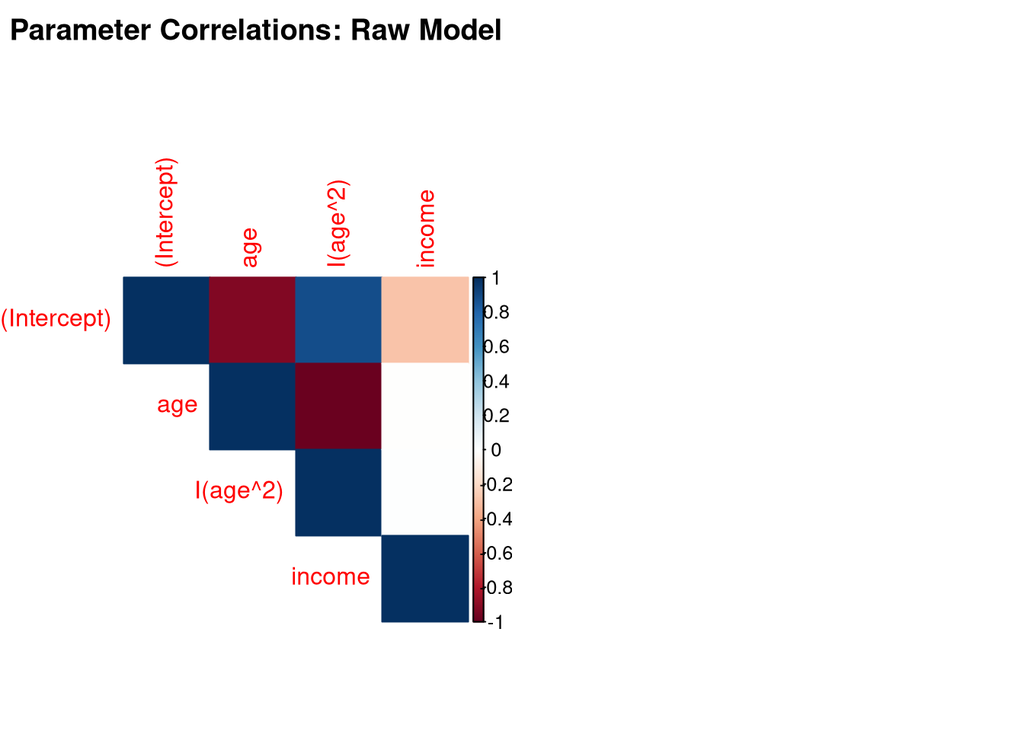

### 4.2.2 Orthogonal Polynomial Model Variance-Covariance Matrix

Variance-Covariance Matrix: Orthogonal Polynomial Model (first 4 parameters)

|  | Intercept | poly(age)1 | poly(age)2 | income |
| --- | --- | --- | --- | --- |
| Intercept | 0.051676 | -0.006651 | -0.019472 | -1e-06 |
| poly(age)1 | -0.006651 | 5.287310 | 0.195185 | 0e+00 |
| poly(age)2 | -0.019472 | 0.195185 | 5.506866 | 0e+00 |
| income | -0.000001 | 0.000000 | 0.000000 | 0e+00 |

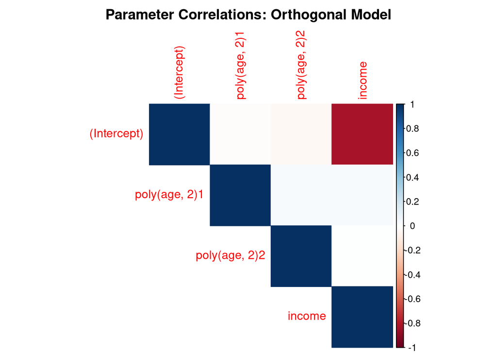

# 4. Marginal Effects

## 4.1 Definition and Interpretation

The marginal effect represents the “instantaneous” rate of change in the outcome with respect to a predictor. For logistic regression on the **log-odds scale**:

$$ME_{\text{log-odds}}(x_k) =
\frac{\partial}{\partial x_k} \log\left(\frac{p}{1-p}\right) =
\frac{\partial \eta}{\partial x_k}$$

where $\eta$ is the linear predictor.

## 4.2 Infinitesimal Approximation

The derivative can be approximated using the definition:

$$\frac{\partial f}{\partial x} = \lim_{h
\to 0} \frac{f(x + h) - f(x)}{h}$$

In practice, we use a small $\epsilon$ (e.g., $\epsilon = 0.001$):

$$ME(x) \approx \frac{f(x + \epsilon) -
f(x)}{\epsilon}$$

## 4.3 Marginal Effects for Different Model Specifications

### 4.3.1 Raw Polynomial Model

For the model: $\eta = \beta_0 + \beta_1 \cdot \text{age} + \beta_2 \cdot \text{age}^2 + \beta_3 \cdot \text{income} + ...$

The marginal effect of age is:
$$ME_{\text{age}} = \frac{\partial \eta}{\partial
\text{age}} = \beta_1 + 2\beta_2 \cdot \text{age}$$

**Key insights:**

- The marginal effect **depends on the current value of age**
- It’s linear in age with slope $2\beta_2$
- At age = $-\frac{\beta_1}{2\beta_2}$, the marginal effect is zero (turning point)
- If the second derivative $f''(x) = 0$ (low bending energy) this can be (carefully) interpreted as the effect of a 1-unit increase.

### Setting Up a Concrete Example

Let’s say we’ve fitted both models and obtained these coefficients:

**Raw Polynomial Model:** - $\beta_1$ (age) = 0.15 - $\beta_2$ (age²) = -0.002

**Interpretation at Different Ages:**

#### At Age 30:

$$ME_{\text{age=30}} = 0.15 +
2(-0.002)(30) = 0.15 - 0.12 = 0.03$$

**Interpretation:** At age 30, a one-year increase in age (from 30 to 31) is associated with an increase of 0.03 in the log-odds of the outcome. This means:

- The odds of the outcome multiply by $e^{0.03} \approx 1.0305$ (about 3% increase in odds)
- If someone aged 30 has 1:1 odds (50% probability), someone aged 31 has 1.03:1 odds (about 50.7% probability)

#### At Age 40:

$$ME_{\text{age=40}} = 0.15 +
2(-0.002)(40) = 0.15 - 0.16 = -0.01$$

**Interpretation:** At age 40, a one-year increase in age is associated with a decrease of 0.01 in the log-odds. This means: - The odds multiply by $e^{-0.01} \approx 0.990$ (about 1% decrease in odds) - The effect of aging has reversed - older individuals now have lower odds

#### At the Turning Point (Age 37.5):

$$\text{Turning point} =
-\frac{\beta_1}{2\beta_2} = -\frac{0.15}{2(-0.002)} = 37.5$$
$$ME_{\text{age=37.5}} = 0.15 +
2(-0.002)(37.5) = 0$$

**Interpretation:** At age 37.5, age has no instantaneous effect on the log-odds. This is where the relationship changes from positive to negative.

### 4.3.2 Orthogonal Polynomial Model

For orthogonal polynomials, the marginal effect calculation is more complex because:

$$\frac{\partial \eta}{\partial
\text{age}} = \beta_1 \frac{\partial P_1(\text{age})}{\partial
\text{age}} + \beta_2 \frac{\partial P_2(\text{age})}{\partial
\text{age}}$$

## 4.4 Practical Calculation and Interpretation

Marginal Effects of Age on Log-Odds Scale

|  | Age | ME.Raw..Numerical. | ME.Raw..Analytical. | ME.Orthogonal |
| --- | --- | --- | --- | --- |
| 1 | 20 | 0.0608 | 0.0608 | 0.0608 |
| 11 | 30 | 0.0428 | 0.0428 | 0.0428 |
| 12 | 40 | 0.0248 | 0.0248 | 0.0248 |
| 13 | 50 | 0.0069 | 0.0069 | 0.0069 |
| 14 | 60 | -0.0111 | -0.0111 | -0.0111 |
| 15 | 70 | -0.0291 | -0.0291 | -0.0291 |
| 16 | 80 | -0.0470 | -0.0470 | -0.0470 |

### 5.4.1 Interpretation Guidelines

**For a marginal effect of 0.05 at age 40:** - A one-year increase in age (from 40 to 41) is associated with an increase of 0.05 in the log-odds - This translates to multiplying the odds by $e^{0.05} \approx 1.051$ (5.1% increase in odds) - The effect on probability depends on the baseline probability

### 5.4.2 Converting to Probability Scale

The marginal effect on the probability scale is:

$$ME_{p}(x) = \frac{\partial p}{\partial
x} = p(1-p) \cdot ME_{\text{log-odds}}(x)$$

Marginal Effects on Different Scales

|  | Age | Baseline.Probability | ME..Log.odds. | ME..Probability. |
| --- | --- | --- | --- | --- |
| 1 | 20 | 0.4723 | 0.0608 | 0.0151 |
| 11 | 30 | 0.6003 | 0.0428 | 0.0103 |
| 12 | 40 | 0.6780 | 0.0248 | 0.0054 |
| 13 | 50 | 0.7116 | 0.0069 | 0.0014 |
| 14 | 60 | 0.7072 | -0.0111 | -0.0023 |
| 15 | 70 | 0.6639 | -0.0291 | -0.0065 |
| 16 | 80 | 0.5745 | -0.0470 | -0.0115 |

## 5.5 Visualization of Marginal Effects

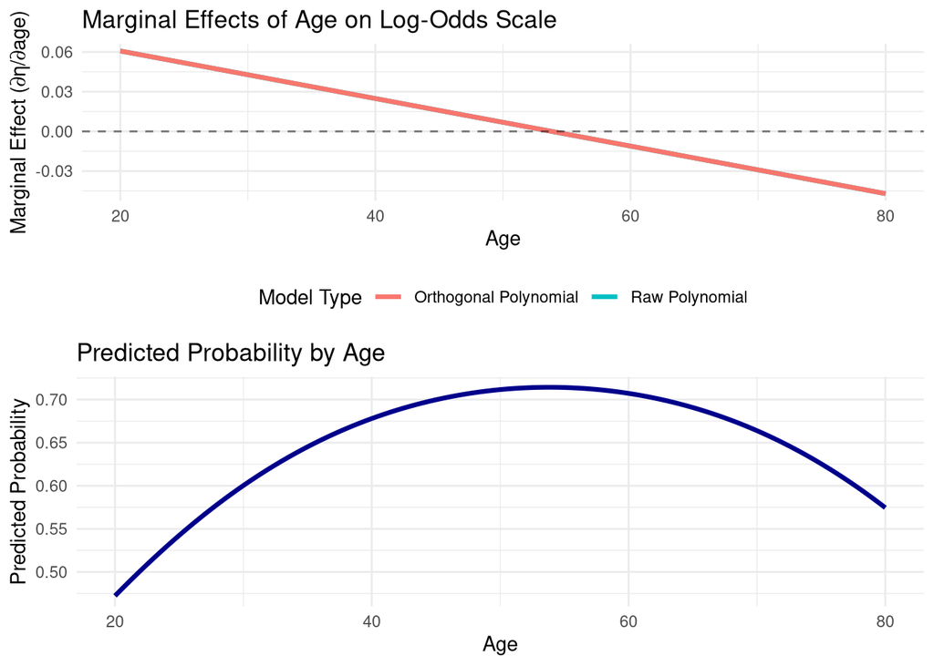

# 6. Model Performance Comparison

## 6.1 Numerical Stability Analysis

1. Convergence Rates
- Does the ML-Algorithm converge.
2. Standard Error Magnitude

Check maximum standard error among the age coefficients (intercept, age, age²). Inflated standard errors indicate multicollinearity and unstable estimates.

Numerical Stability Under Different Conditions

| Age.Range | Raw.Convergence | Orthogonal.Convergence | Mean.Max.SE..Raw. | Mean.Max.SE..Orth. |
| --- | --- | --- | --- | --- |
| 20-80 (Normal) | 1 | 1 | 0.677 | 2.340 |
| 40-50 (Narrow) | 1 | 1 | 21.899 | 2.565 |
| 0-100 (Wide) | 1 | 1 | 0.298 | 2.323 |

# 8. Matrix Stuff (Red Pill or Blue Pill?)

## 8.1 Proof of Orthogonality Benefits

**Theorem:** For orthogonal design matrix $\mathbf{X}$ where $\mathbf{X}^T\mathbf{X} = \text{diag}(d_1, ..., d_p)$, the variance of $\hat{\beta}_j$ is minimized.

**Proof:** The variance-covariance matrix is:
$$\text{Var}(\hat{\boldsymbol{\beta}}) =
\sigma^2(\mathbf{X}^T\mathbf{X})^{-1}$$

For orthogonal $\mathbf{X}$:
$$(\mathbf{X}^T\mathbf{X})^{-1} =
\text{diag}(1/d_1, ..., 1/d_p)$$

Thus: $\text{Var}(\hat{\beta}_j) = \sigma^2/d_j$

For non-orthogonal $\mathbf{X}$, off-diagonal elements in $(\mathbf{X}^T\mathbf{X})^{-1}$ increase the variance.

## 8.2 Relationship Between Parameterizations

The predictions from both models are identical because:

$$\mathbf{X}_{\text{raw}}\boldsymbol{\beta}_{\text{raw}}
= \mathbf{X}_{\text{orth}}\boldsymbol{\beta}_{\text{orth}}$$

This follows from the fact that both span the same column space.